# 红酒品质的影响因素与分类预测

#### 1.3.5.4 评估

如下，在对使用的机器学习方法进行评估时，我使用了如下指标：混淆矩阵，ROC曲线，AUC等。其中以AUC为主要的预测准确度评判标准。

部分参数解释：

精度(precision) = 正确预测的个数(TP)/被预测正确的个数(TP+FP)

召回率(recall)=正确预测的个数(TP)/预测个数(TP+FN)

F1 = 2*精度*召回率/(精度+召回率)

avg/total：等于各指标的加权平均值

```
[[381  34]
 [ 30  35]]
             precision    recall  f1-score   support

          0       0.93      0.92      0.92       415
          1       0.51      0.54      0.52        65

avg / total       0.87      0.87      0.87       480
```

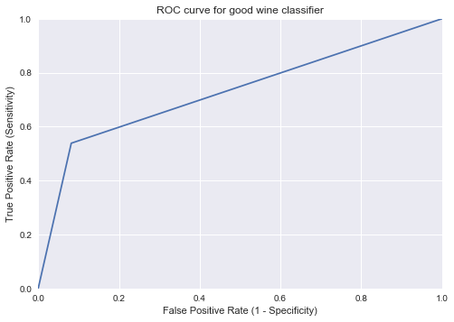

```python
#评估决策树
fpr1, tpr1, thresholds = metrics.roc_curve(expected1, predicted1)
plt.plot(fpr1, tpr1)
plt.xlim([0.0, 1.0])
plt.ylim([0.0, 1.0])
plt.title('ROC curve for good wine classifier')
plt.xlabel('False Positive Rate (1 - Specificity)')
plt.ylabel('True Positive Rate (Sensitivity)')
plt.grid(True)
auc1 = roc_auc_score(expected1, predicted1)
auc1
print(metrics.confusion_matrix(expected1, predicted1))
print(metrics.classification_report(expected1, predicted1))
```

```
[[403  10]
 [ 55  12]]
             precision    recall  f1-score   support

          0       0.88      0.98      0.93       413
          1       0.55      0.18      0.27        67

avg / total       0.83      0.86      0.83       480
```

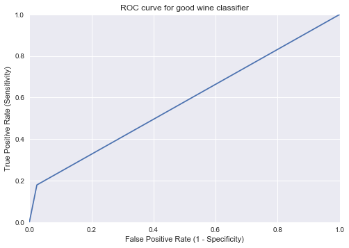

```python
#评估向量机
fpr2, tpr2, thresholds = metrics.roc_curve(expected2, predicted2)
plt.plot(fpr2, tpr2)
plt.xlim([0.0, 1.0])
plt.ylim([0.0, 1.0])
plt.title('ROC curve for good wine classifier')
plt.xlabel('False Positive Rate (1 - Specificity)')
plt.ylabel('True Positive Rate (Sensitivity)')
plt.grid(True)
auc2 = roc_auc_score(expected2, predicted2)
auc2
print(metrics.confusion_matrix(expected2, predicted2))
print(metrics.classification_report(expected2, predicted2))
```

```
[[403  12]
 [ 53  12]]
             precision    recall  f1-score   support

          0       0.88      0.97      0.93       415
          1       0.50      0.18      0.27        65

avg / total       0.83      0.86      0.84       480
```

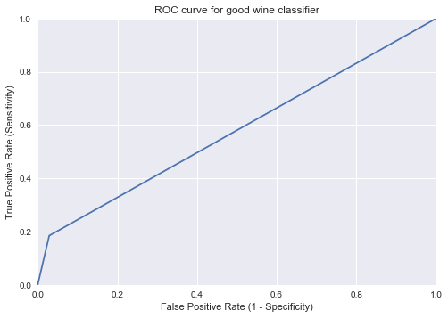

```python
#评估逻辑回归
fpr3, tpr3, thresholds = metrics.roc_curve(expected3, predicted3)
plt.plot(fpr3, tpr3)
plt.xlim([0.0, 1.0])
plt.ylim([0.0, 1.0])
plt.title('ROC curve for good wine classifier')
plt.xlabel('False Positive Rate (1 - Specificity)')
plt.ylabel('True Positive Rate (Sensitivity)')
plt.grid(True)
auc3 = roc_auc_score(expected3, predicted3)
auc3
print(metrics.confusion_matrix(expected3, predicted3))
print(metrics.classification_report(expected3, predicted3))
```

```python
auc1,auc2,auc3
```

```
(0.72826691380908237, 0.57744570127570383, 0.57784986098239111)
```

从AUC数值来看，决策树的分类方法明显优于svm和逻辑回归，因此在本语境下，如果想要通过红酒的各类指标去预测其对应的‘quality’，推荐使用决策树方法。

## 1.4 分析结论

（1）在决定红酒‘quality’的物理化学因素中，‘alcohol’（酒精含量）和‘volatile acidity’（挥发性酸度）与其的相关性最大；包含‘residual sugar’（残余甜度）在内的其他指标与‘quality’的关系不大。 （2）‘density’（密度）与‘fixed acidity’（固定酸度）之间有较强的线性回归关系。 （2）在分别使用了决策树、向量机和逻辑回归这三种机器学习方法后，对于本情况，使用决策树法有最高的AUC（0.73），是三者中的最优选择。 （3）数据中的离群点需要进行恰当清洗，从而减少因它而带来的误差。

## 1.5 参考文献

[1]数据来源：https://www.kaggle.com/anikeshishyan/random-forest-analysis-on-red-wine-data/data

P. Cortez, A. Cerdeira, F. Almeida, T. Matos and J. Reis. Modeling wine preferences by data mining from physicochemical properties. In Decision Support Systems, Elsevier, 47(4):547-553, 2009.